# Reproductive Cycle and Gametogenesis on Sea Anemones: a Sistematic Review

Rafael Brandão

18/09/2021

# Introduction

The modes of reproduction in sea anemones may be quite variable depending on the species and the environmental conditions (Bocharova and Kozevich 2011).

# Material and Methods

In order to get a first glimpse on the universe of articles regarding the field of reproduction on sea anemones we have extracted data from Web of Science using the search line (“sea anemone” OR actiniari*) AND reproducti*. All search results obtained from this search were exported. Using this data we created a thesaurus for the Keywords to avoid bias caused by overlap of terms and did a co-occurence analysis using the VosViewer software.  
For the extensive data extraction we have used three different platforms, Web of Science, Scopus and ScienceDirect. The searching engine used was (“actiniaria” OR “sea anemone”) AND (spermatogenesis OR “reproductive cycle” OR “sexual reproduction” OR oogenesis OR “reproductive biology” OR gametogenesis). The use of special characters such as * was conditioned to each platform. The search was set to filter preceding papers but included reviews and book chapters.  
Due to a low number of articles obtained after the first screening we have proceded with a forward and backward searching. For that pourpose we used four articles, Dunn (1970), Scott & Harisson (2009) and Bocharova & Kozevich (2011) and Young et al. 2021. The first two were chosen due to citation numbers, the third one is the most a recent review on sea anemone reproduction and the last one presents a comprehensive table of articles focused on reproductive studies.

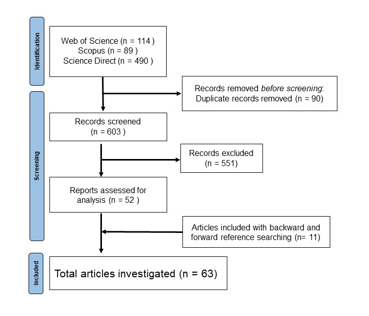

# Results

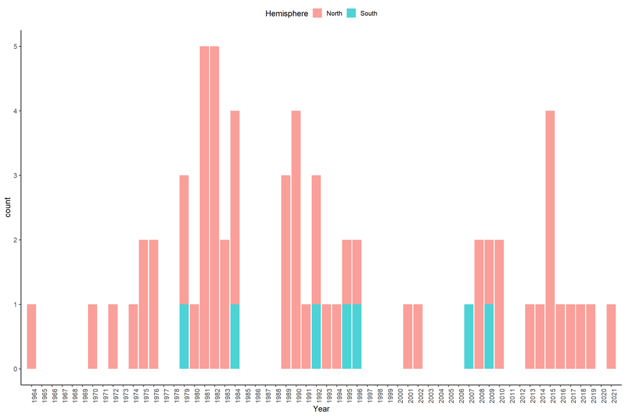

**Figure 2**. Number of studies published during the last 50 year

| ï..xx | Year | N.authors | Title | First.Author.Country | Sampling | Hemisphere | Species | Genera | Family | Periodicity | Sampling.lenght | Oocyte.mesurement | Spermaries.classification | Temp.Sal.report |
| --- | --- | --- | --- | --- | --- | --- | --- | --- | --- | --- | --- | --- | --- | --- |
| x | 1994 | 2 | Effects of flow-habitat on body size and reproductive patterns in the sea anemone Metridium senile in the Gullmarsfjord, Sweden | Sweden | Baltico | North | Metridium senile | Metridium | Metridiidae | Monthly | 6 months | Yes | No | No |
| x | 1972 | 2 | An Ultrostructural Investigation of Spermiogenesis and the Mature Sperm in the Anthozoan Bunodosoma cavernata (Cnidaria) | USA | Gulf of Texas | North | Bunodosoma cavernata | Bunodosoma | Actiniidae |  |  |  |  |  |
| x | 2014 | 5 | Trioecy, a Unique Breeding Strategy in the Sea anemone Aiptasia diaphana and its association with Sex Steroids | Israel | Red Sea | North | Aiptasia diaphana | Aiptasia | Aiptasiidae | Weekly | 9 weeks | Yes | Yes | No |
| x | 2015 | 4 | Seasonal Gametogenesis of Host Sea Anemone (Entacmaea quadricolor) Inhabiting Hong Kong Waters | China | China Sea | North | Entacmaea quadricolor | Entacmaea | Actiniidae | Monthly | 12 months | Yes | Yes | Yes |
| x | 1996 | 2 | Genetic subdivision in the subtidal, clonal sea anemone Anthothoe albocincta | England | Tasman Sea | South | Anthothoe albocincta | Anthothoe | Sargatiidae | Monthly | 7 months | Yes | No | No |
|  | 2015 | 1 | Reproductive Biology and Genetic Diversity of the sea anemone Aulactinia stella (Verril, 1864) | Russia | White Sea and Barents Sea and Bering Sea | North | Aulactinia stella | Aulactinia | Actiniidae |  |  |  |  |  |
|  | 1993 | 4 | Reproductive Biology of two epizoic anemones from the deep north-eastern atlantic ocean | United Kingdom | Porcupine Abyssal Plain | North | Amphianthus inornata | Amphianthus | Amphianthidae |  | 7 years | Yes | Yes | No |
|  | NA | 4 | Reproductive Biology of two epizoic anemones from the deep north-eastern atlantic ocean | United Kingdom | Porcupine Abyssal Plain | North | Kadosactis commensalis | Kadosactis | Kadosactinidae |  | 12 years | Yes | Yes | No |
|  | 1982 | 1 | The annual cycle of sexual reproduction in the sea anemone Metridium senile | USA | Bodega Bay | North | Metridium senile | Metridium | Metridiidae | Monthly | 4 years | Yes | Yes | No |
|  | 2016 | 3 | Body size and symbiotic status influence gonad development in Aiptasia pallida | USA | Laboratory | North | Aiptasia pallida | Exaiptasia | Aiptasiidae | Weekly | 9 weeks | No | No | No |

[output cut: 67 more lines]

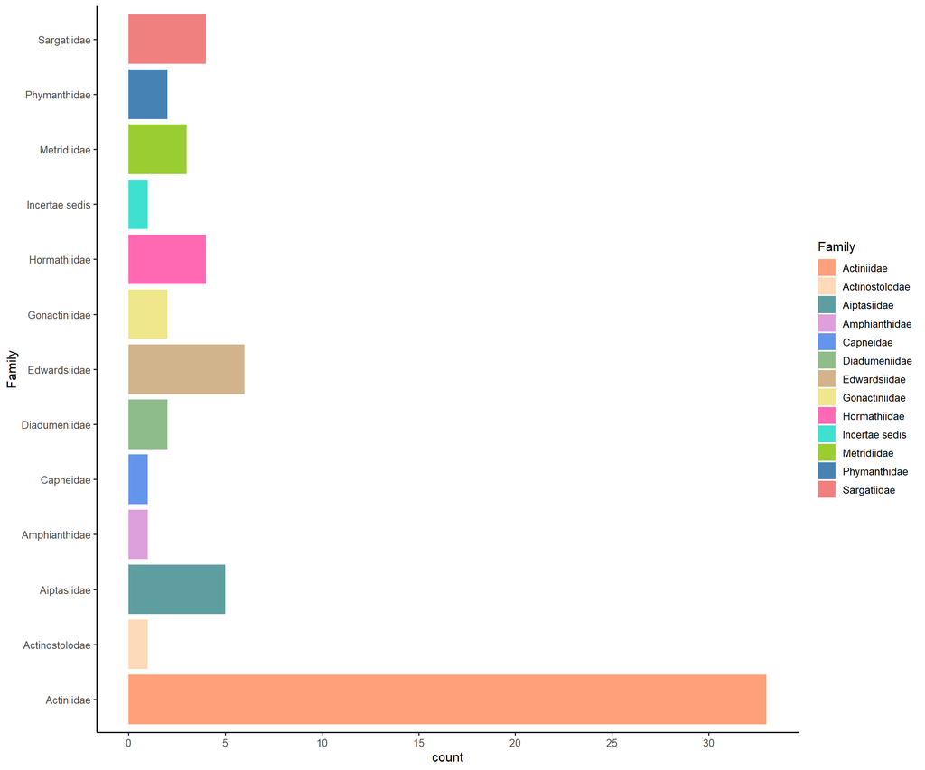

**Figure 3.** Number of studies published per family.

| ï..x | Species | X | Family | Hemisphere | months | maturity |
| --- | --- | --- | --- | --- | --- | --- |
| x | Entacmaea quadricolor |  | Actiniidae | NA | September | 1 |
| x | Entacmaea quadricolor |  | Actiniidae | NA | October | 1 |
|  | Anthothoe albocincta | South | Sargatiidae | NA | March | 1 |
|  | Anthothoe albocincta | South | Sargatiidae | NA | April | 1 |
|  | Metridium senile |  | Metridiidae | NA | August | 1 |
|  | Metridium senile |  | Metridiidae | NA | September | 1 |
|  | Actinia equina |  | Actiniidae | NA | June | 1 |
|  | Actinia equina |  | Actiniidae | NA | July | 1 |
|  | Actinia equina |  | Actiniidae | NA | August | 1 |
|  | Anthopleura elegantissima |  | Actiniidae | NA | September | 1 |

[output cut: 90 more lines]